# 财务因子深度分析

陶阿明

2017/06/21

今年以来，市值和反转因子表现不佳，财务因子的关注度得到提升，风水轮流转。每一个因子都有其周期，没有长青的因子，尤其过去几年表现抢眼的因子不可避免的会遇到均值回复宿命。

## 一、因子综述

### (一)因子简介

eps过去三年均值除以标准差，由于要用到过去三年的财务数据，上市不足三年的股票数值为空，用行业中值代替。

### (二)因子效果展示

因子IC序列如下图所示：

```
## [memory data loading]
##   Loading the market trading days: '.tradingdays' ...
##   Loading the SQLite memory database. You can run DBI::dbListTables(.con_memory) to get the loaded table list
```

```
## Function getTSF: getting the factorscore ....
## Tinysoft logined.
```

```
## Function getTSR: getting the periodrtn ....
```

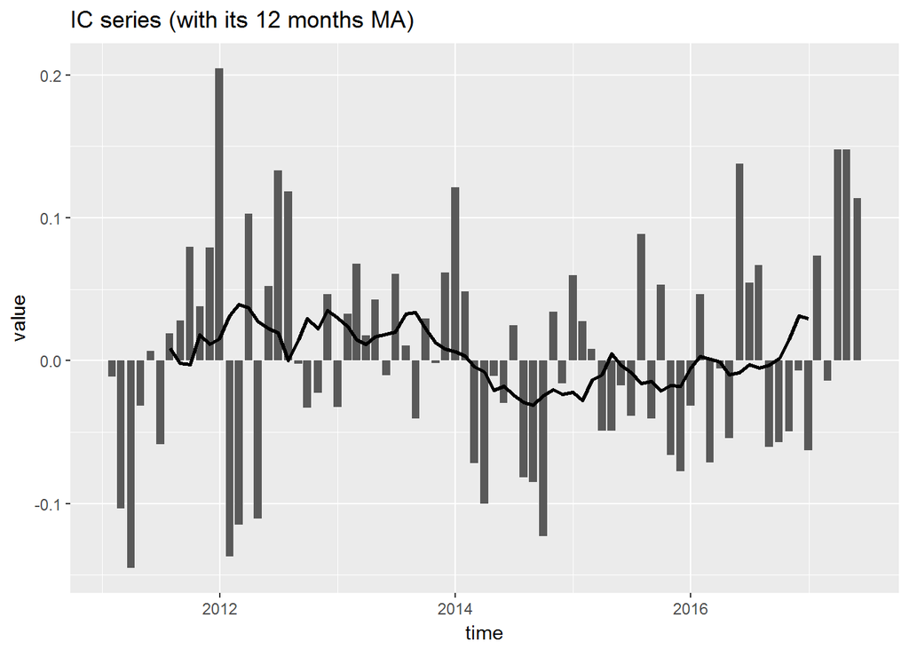

因子分组的年化收益率如下图所示：

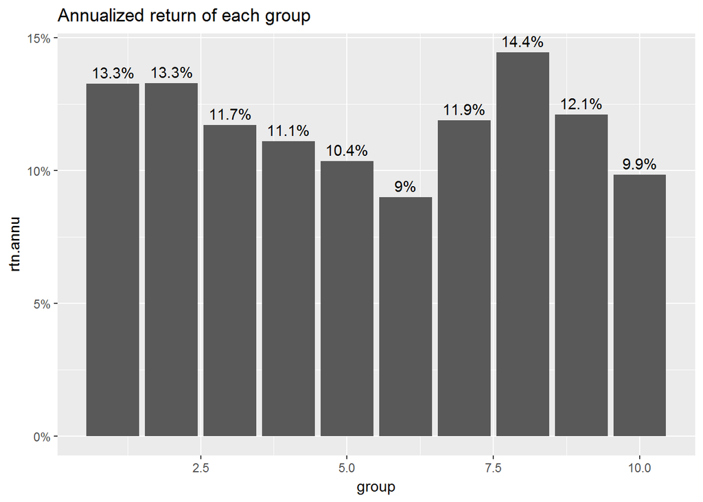

因子多空收益如下图所示：

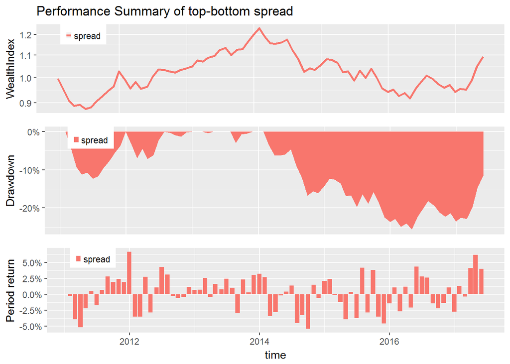

### (三)纯因子组合

上述因子IC、因子分组、因子多空组合不能剥离行业、市值等风格特征。下面构建的纯因子组合是剔除了市值、行业之后的纯因子组合，更能有效的反映因子的alpha性。

纯因子组合收益率如下图所示：

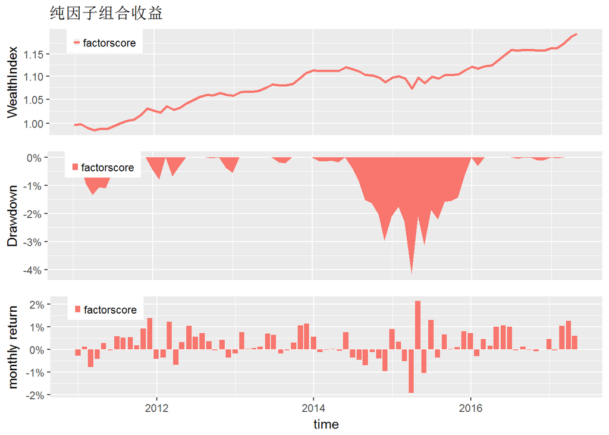

纯因子组合收益率统计如下表：

|  | factorscore |
| --- | --- |
| 2010-12-31 ~ 2010-12-31 | -0.3% |
| 2011-01-31 ~ 2011-12-30 | 2.9% |
| 2012-01-31 ~ 2012-12-31 | 3% |
| 2013-01-31 ~ 2013-12-31 | 5.3% |
| 2014-01-30 ~ 2014-12-31 | -1.5% |
| 2015-01-30 ~ 2015-12-31 | 2.2% |
| 2016-01-29 ~ 2016-12-30 | 3.9% |
| 2017-01-26 ~ 2017-04-28 | 2.9% |
| Cumulative Return | 19.8% |
| Annualized Return | 2.8% |
| Annualized StdDev | 2.3% |
| Annualized Sharpe(Rf=0%) | 125.1% |
| Worst Drawdown | 4.2% |

## 二、核心指数回测

上面的测试都是全市场测试，下面将在沪深300和中证500里面分别测试因子的效果。

### (一)沪深300

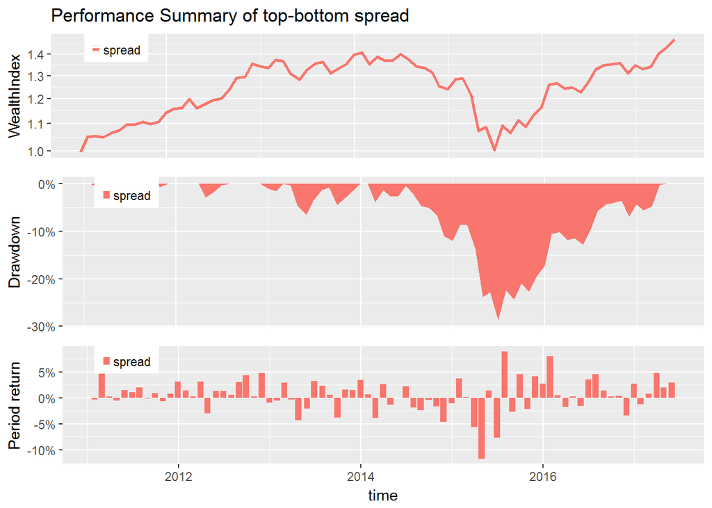

### (二)中证500

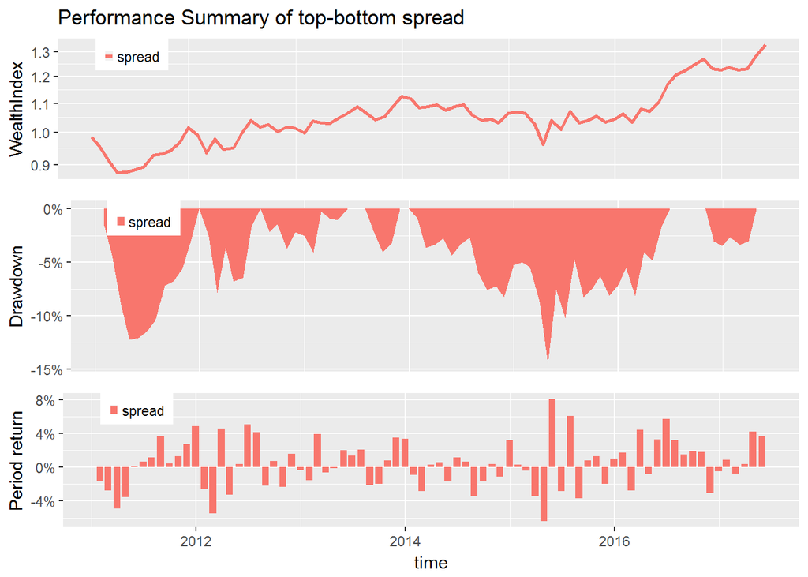

### (三)指数统计

两个指数中因子的IC统计和因子的多空组合收益率如下表所示

|  | EI000300 | EI000905 |
| --- | --- | --- |
| IC均值 | 0.029 | 0.023 |
| IC标准差 | 0.081 | 0.071 |
| ICIR | 0.354 | 0.322 |
| IC胜率 | 0.584 | 0.610 |
| 多空组合年化收益 | 0.062 | 0.046 |
| 多空组合年化波动率 | 0.111 | 0.100 |
| 多空组合年化夏普 | 0.559 | 0.458 |
| 多空组合最大回撤 | 0.287 | 0.145 |

## 三、大类行业回测

### (一)大周期

大周期覆盖农林牧渔、采掘、化工、钢铁、有色金属。

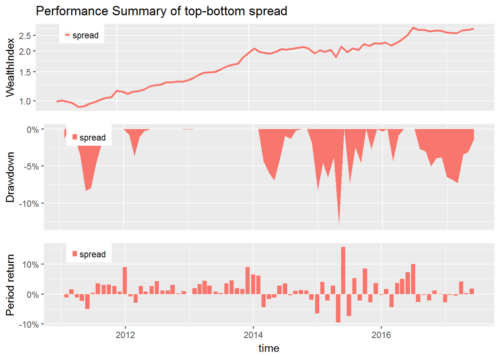

### (二)金融地产

金融地产组覆盖银行、非银、房地产。

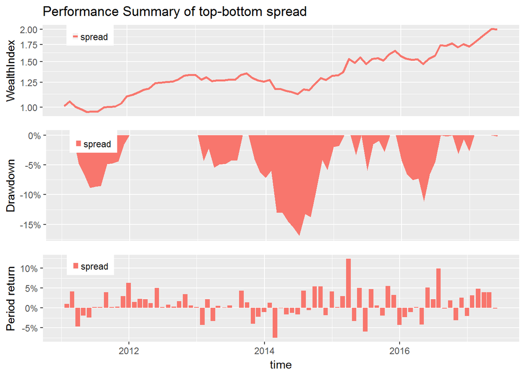

### (三)TMT

TMT覆盖电子、计算机、传媒、通信。

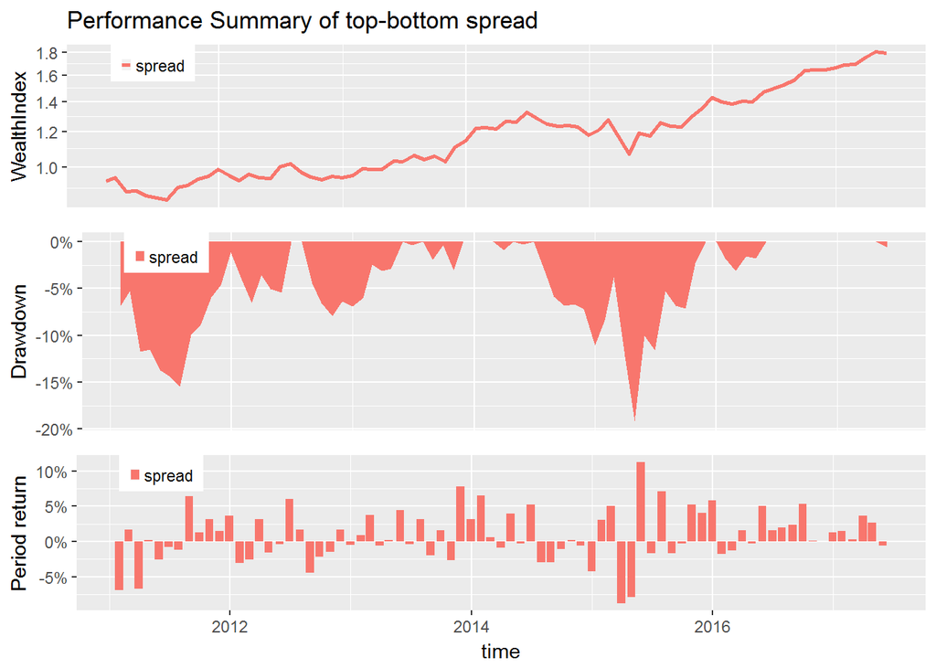

### (四)大消费

大消费覆盖汽车、家用电器、食品饮料、纺织服装、休闲服务、医药生物、商业贸易。

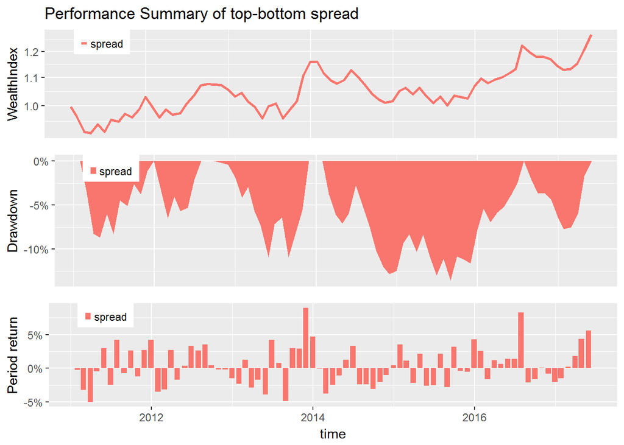

### (五)制造组

制造组覆盖轻工制造、建筑材料、建筑建材、电气设备、机械设备、国防军工。

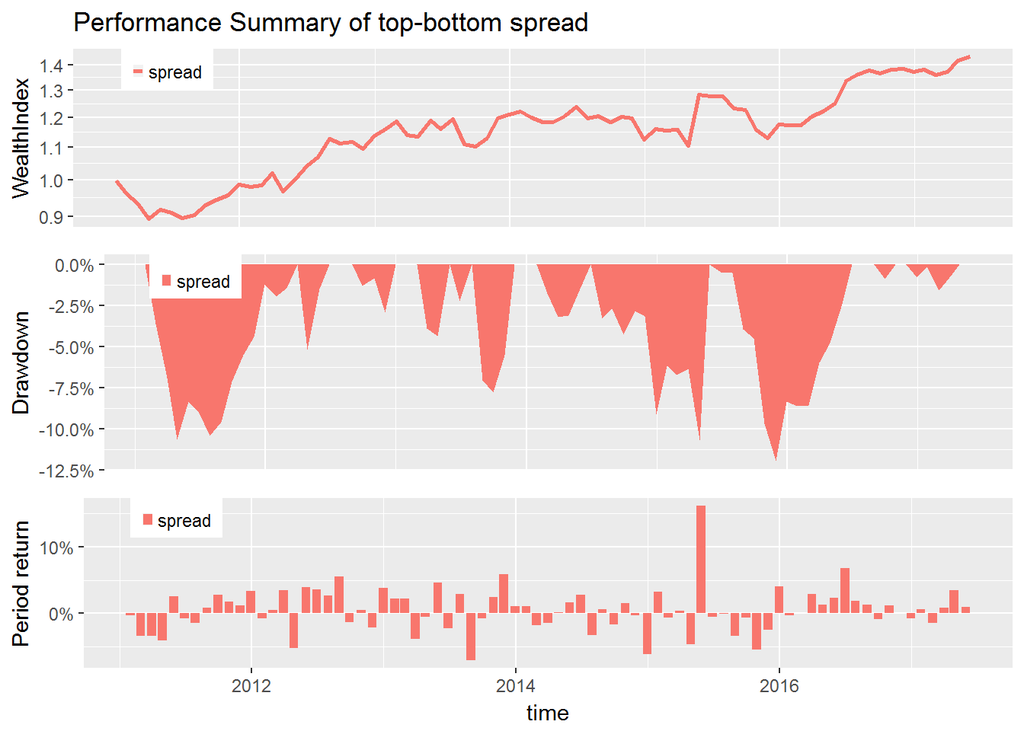

### (六)其他

其他覆盖公共事业、交通运输、综合。

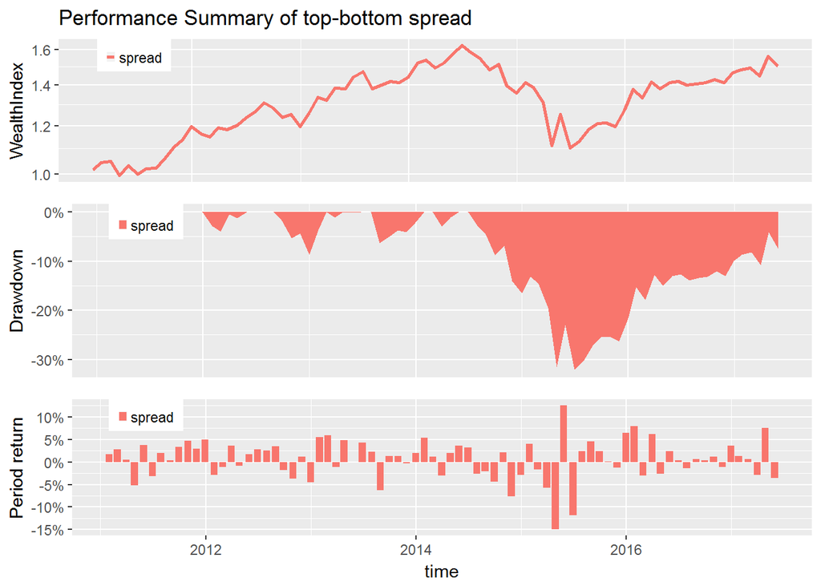

### (七)行业统计

大类行业中因子的IC统计和因子的多空组合收益率如下表所示

|  | 周期 | 金融地产 | TMT | 消费 | 制造 | 其他 |
| --- | --- | --- | --- | --- | --- | --- |
| IC均值 | 0.033 | 0.025 | 0.017 | 0.018 | 0.015 | 0.019 |
| IC标准差 | 0.089 | 0.090 | 0.075 | 0.065 | 0.064 | 0.091 |
| ICIR | 0.373 | 0.271 | 0.222 | 0.279 | 0.234 | 0.210 |
| IC胜率 | 0.610 | 0.571 | 0.584 | 0.545 | 0.571 | 0.597 |
| 多空组合年化收益 | 0.170 | 0.114 | 0.096 | 0.038 | 0.058 | 0.065 |
| 多空组合年化波动率 | 0.138 | 0.119 | 0.126 | 0.101 | 0.116 | 0.148 |
| 多空组合年化夏普 | 1.235 | 0.958 | 0.760 | 0.377 | 0.499 | 0.442 |
| 多空组合最大回撤 | 0.130 | 0.169 | 0.191 | 0.136 | 0.119 | 0.320 |